# Homework 6

Caroline Andy

12/6/2020

### Problem 1

```r
library(purrr)
library(tidyverse)
library(stringr)
library(patchwork)
library(skimr)
library(modelr)

knitr::opts_chunk$set(
  fig.width = 6,
  fig.asp = .6,
  out.width = "90%"
)
```

```r
#generate homicide table and summarize solved and unsolved murders by state
homicide =
  read_csv("homicide-data.csv", na = c("", "NA", "Unknown")) %>%
  drop_na() %>%
  mutate(
    city_state = str_c(city, state, sep = ", "),
    victim_age = as.numeric(victim_age),
    victim_sex = as.factor(victim_sex),
    resolution = case_when(
      disposition %in% "Closed without arrest" ~ 0,
      disposition %in% "Closed by arrest" ~ 1,
      disposition %in% "Open/No arrest" ~ 0)) %>%
  filter(
    victim_race %in% c("White", "Black"),
    !(city_state %in% c("Tulsa, AL", "Dallas, TX", "Phoenix, AZ", "Kansas City, MO"))) %>%
  mutate(
    victim_race = as.factor(victim_race),
    victim_race = as.character(victim_race),
    victim_sex = as.character(victim_sex)
  ) %>%
  select(city_state, resolution, victim_age, victim_race, victim_sex)
skim(homicide)
```

Data summary

| Name | homicide |
| --- | --- |
| Number of rows | 37168 |
| Number of columns | 5 |
| _______________________ |  |
| Column type frequency: |  |
| character | 3 |
| numeric | 2 |
| ________________________ |  |
| Group variables | None |

**Variable type: character**

| skim_variable | n_missing | complete_rate | min | max | empty | n_unique | whitespace |
| --- | --- | --- | --- | --- | --- | --- | --- |
| city_state | 0 | 1 | 9 | 18 | 0 | 43 | 0 |
| victim_race | 0 | 1 | 5 | 5 | 0 | 2 | 0 |
| victim_sex | 0 | 1 | 4 | 6 | 0 | 2 | 0 |

**Variable type: numeric**

| skim_variable | n_missing | complete_rate | mean | sd | p0 | p25 | p50 | p75 | p100 | hist |
| --- | --- | --- | --- | --- | --- | --- | --- | --- | --- | --- |
| resolution | 0 | 1 | 0.48 | 0.50 | 0 | 0 | 0 | 1 | 1 | ▇▁▁▁▇ |
| victim_age | 0 | 1 | 31.85 | 14.32 | 0 | 22 | 28 | 39 | 101 | ▂▇▂▁▁ |

Start with one city.

```r
baltimore_df =
  homicide %>%
  filter(city_state == "Baltimore, MD")

glm(resolution ~ victim_age + victim_race + victim_sex,
    data = baltimore_df,
    family = binomial()) %>%
  broom::tidy() %>%
  mutate(
    OR = exp(estimate),
    CI_lower = exp(estimate - 1.96 * std.error),
    CI_upper = exp(estimate + 1.96 * std.error)
  ) %>%
  select(term, OR, starts_with("CI")) %>%
  knitr::kable(digits = 3)
```

| term | OR | CI_lower | CI_upper |
| --- | --- | --- | --- |
| (Intercept) | 1.363 | 0.975 | 1.907 |
| victim_age | 0.993 | 0.987 | 1.000 |
| victim_raceWhite | 2.320 | 1.648 | 3.268 |
| victim_sexMale | 0.426 | 0.325 | 0.558 |

Try this across cities.

```r
model_results_df =
  homicide %>%
  nest(data = -city_state) %>%
  mutate(
    models =
      map(.x = data, ~glm(resolution ~ victim_age+victim_sex, data = .x, family = binomial())),
    results = map(models, broom::tidy)
) %>%
  select(city_state, results) %>%
  unnest(results) %>%
  mutate(
    OR = exp(estimate),
    CI_lower = exp(estimate - 1.96 * std.error),
    CI_upper = exp(estimate + 1.96 * std.error)
  ) %>%
  select(city_state, term, OR, starts_with("CI"))

summary(homicide)
```

```
##   city_state          resolution       victim_age     victim_race
##  Length:37168       Min.   :0.0000   Min.   :  0.00   Length:37168
##  Class :character   1st Qu.:0.0000   1st Qu.: 22.00   Class :character
##  Mode  :character   Median :0.0000   Median : 28.00   Mode  :character
##                     Mean   :0.4848   Mean   : 31.85
##                     3rd Qu.:1.0000   3rd Qu.: 39.00
##                     Max.   :1.0000   Max.   :101.00
##   victim_sex
##  Length:37168
##  Class :character
##  Mode  :character
##
##
##
```

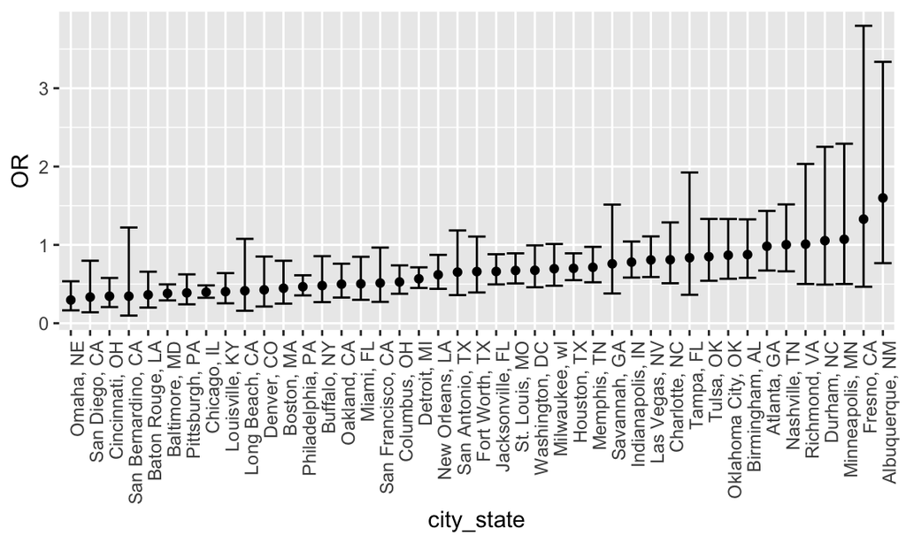

```r
model_results_df %>%
  filter(term == "victim_sexMale") %>%
  mutate(city_state = fct_reorder(city_state, OR)) %>%
  ggplot(aes(x = city_state, y = OR)) +
  geom_point() +
  geom_errorbar(aes(ymin = CI_lower, ymax = CI_upper)) +
  theme(axis.text.x = element_text(angle = 90, hjust = 1))
```

### Problem 2

In this problem, I will analyze data gathered to understand the effects of several variables on a child’s birthweight. This dataset consists of roughly 4000 children and includes 20 variables, including baby sex, head circumference, length, gestational age, and mother’s age, age at menarche, height, race and previous pregnancy outcomes.

Here I will load and clean the data for regression analysis, converting numeric variables to factor variables where appropriate, and checking for missing values.

```r
bweight = read_csv("./birthweight.csv")
skim(bweight)
```

Data summary

| Name | bweight |
| --- | --- |
| Number of rows | 4342 |
| Number of columns | 20 |
| _______________________ |  |
| Column type frequency: |  |
| numeric | 20 |
| ________________________ |  |
| Group variables | None |

**Variable type: numeric**

| skim_variable | n_missing | complete_rate | mean | sd | p0 | p25 | p50 | p75 | p100 | hist |
| --- | --- | --- | --- | --- | --- | --- | --- | --- | --- | --- |
| babysex | 0 | 1 | 1.49 | 0.50 | 1.00 | 1.00 | 1.00 | 2.00 | 2.0 | ▇▁▁▁▇ |
| bhead | 0 | 1 | 33.65 | 1.62 | 21.00 | 33.00 | 34.00 | 35.00 | 41.0 | ▁▁▆▇▁ |
| blength | 0 | 1 | 49.75 | 2.72 | 20.00 | 48.00 | 50.00 | 51.00 | 63.0 | ▁▁▁▇▁ |
| bwt | 0 | 1 | 3114.40 | 512.15 | 595.00 | 2807.00 | 3132.50 | 3459.00 | 4791.0 | ▁▁▇▇▁ |
| delwt | 0 | 1 | 145.57 | 22.21 | 86.00 | 131.00 | 143.00 | 157.00 | 334.0 | ▅▇▁▁▁ |
| fincome | 0 | 1 | 44.11 | 25.98 | 0.00 | 25.00 | 35.00 | 65.00 | 96.0 | ▃▇▅▂▃ |
| frace | 0 | 1 | 1.66 | 0.85 | 1.00 | 1.00 | 2.00 | 2.00 | 8.0 | ▇▁▁▁▁ |
| gaweeks | 0 | 1 | 39.43 | 3.15 | 17.70 | 38.30 | 39.90 | 41.10 | 51.3 | ▁▁▂▇▁ |
| malform | 0 | 1 | 0.00 | 0.06 | 0.00 | 0.00 | 0.00 | 0.00 | 1.0 | ▇▁▁▁▁ |
| menarche | 0 | 1 | 12.51 | 1.48 | 0.00 | 12.00 | 12.00 | 13.00 | 19.0 | ▁▁▂▇▁ |
| mheight | 0 | 1 | 63.49 | 2.66 | 48.00 | 62.00 | 63.00 | 65.00 | 77.0 | ▁▁▇▂▁ |
| momage | 0 | 1 | 20.30 | 3.88 | 12.00 | 18.00 | 20.00 | 22.00 | 44.0 | ▅▇▂▁▁ |
| mrace | 0 | 1 | 1.63 | 0.77 | 1.00 | 1.00 | 2.00 | 2.00 | 4.0 | ▇▇▁▁▁ |
| parity | 0 | 1 | 0.00 | 0.10 | 0.00 | 0.00 | 0.00 | 0.00 | 6.0 | ▇▁▁▁▁ |
| pnumlbw | 0 | 1 | 0.00 | 0.00 | 0.00 | 0.00 | 0.00 | 0.00 | 0.0 | ▁▁▇▁▁ |
| pnumsga | 0 | 1 | 0.00 | 0.00 | 0.00 | 0.00 | 0.00 | 0.00 | 0.0 | ▁▁▇▁▁ |
| ppbmi | 0 | 1 | 21.57 | 3.18 | 13.07 | 19.53 | 21.03 | 22.91 | 46.1 | ▃▇▁▁▁ |
| ppwt | 0 | 1 | 123.49 | 20.16 | 70.00 | 110.00 | 120.00 | 134.00 | 287.0 | ▅▇▁▁▁ |
| smoken | 0 | 1 | 4.15 | 7.41 | 0.00 | 0.00 | 0.00 | 5.00 | 60.0 | ▇▁▁▁▁ |
| wtgain | 0 | 1 | 22.08 | 10.94 | -46.00 | 15.00 | 22.00 | 28.00 | 89.0 | ▁▁▇▁▁ |

```r
# no missing values, all variables are numeric

# convert sex, race and malformation variable to factors
bweight = bweight %>%
  mutate(babysex = (fct_infreq(as.factor(babysex))),
         frace = (fct_infreq(as.factor(frace))),
         mrace = (fct_infreq(as.factor(mrace))),
         malform = (fct_infreq(as.factor(malform))))
```

Now I will propose a regression model for birthweight using backwards stepwise selection with the step() function.

```r
## function for backward stepwise selection
mult.fit <- lm(bwt ~ ., data = bweight)
step(mult.fit, direction = 'backward')
```

```
## Start:  AIC=48717.83
## bwt ~ babysex + bhead + blength + delwt + fincome + frace + gaweeks +
##     malform + menarche + mheight + momage + mrace + parity +
##     pnumlbw + pnumsga + ppbmi + ppwt + smoken + wtgain
##
##
## Step:  AIC=48717.83
## bwt ~ babysex + bhead + blength + delwt + fincome + frace + gaweeks +
##     malform + menarche + mheight + momage + mrace + parity +
##     pnumlbw + pnumsga + ppbmi + ppwt + smoken
##
##
## Step:  AIC=48717.83
## bwt ~ babysex + bhead + blength + delwt + fincome + frace + gaweeks +
##     malform + menarche + mheight + momage + mrace + parity +
##     pnumlbw + ppbmi + ppwt + smoken
##
##
## Step:  AIC=48717.83
## bwt ~ babysex + bhead + blength + delwt + fincome + frace + gaweeks +
##     malform + menarche + mheight + momage + mrace + parity +
##     ppbmi + ppwt + smoken
##
##            Df Sum of Sq       RSS   AIC
## - frace     4    124365 320848704 48712
## - malform   1      1419 320725757 48716
## - ppbmi     1      6346 320730684 48716
## - momage    1     28661 320752999 48716
## - mheight   1     66886 320791224 48717
## - menarche  1    111679 320836018 48717
## - ppwt      1    131132 320855470 48718
## <none>                  320724338 48718
## - fincome   1    193454 320917792 48718
## - parity    1    413584 321137922 48721
## - mrace     3    868321 321592659 48724
## - babysex   1    853796 321578134 48727
## - gaweeks   1   4611823 325336161 48778
## - smoken    1   5076393 325800732 48784
## - delwt     1   8008891 328733230 48823
## - blength   1 102050296 422774634 49915
```

[output cut: 88 more lines]

```
##     mheight + mrace + parity + ppwt + smoken
##
##           Df Sum of Sq       RSS   AIC
## <none>                 320986412 48705
## - fincome  1    245637 321232048 48707
## - parity   1    422770 321409181 48709
## - babysex  1    846134 321832545 48715
## - mheight  1   1012240 321998651 48717
## - ppwt     1   2907049 323893461 48743
## - gaweeks  1   4662501 325648912 48766
## - smoken   1   5073849 326060260 48771
## - delwt    1   8137459 329123871 48812
## - mrace    3  14683609 335670021 48894
## - blength  1 102191779 423178191 49903
## - bhead    1 106779754 427766166 49950
```

```
##
## Call:
## lm(formula = bwt ~ babysex + bhead + blength + delwt + fincome +
##     gaweeks + mheight + mrace + parity + ppwt + smoken, data = bweight)
##
## Coefficients:
## (Intercept)     babysex2        bhead      blength        delwt      fincome
##   -6098.822       28.558      130.777       74.947        4.107        0.318
##     gaweeks      mheight       mrace2       mrace4       mrace3       parity
##      11.592        6.594     -138.792     -100.678      -74.887       96.305
##        ppwt       smoken
##      -2.676       -4.843
```

```r
## final proposed model based on backward stepwise selection:
reg = lm(bwt ~ babysex + bhead + blength + delwt + fincome + gaweeks +
    mheight + mrace + parity + ppwt + smoken, data = bweight)

reg %>%
  broom::tidy() %>%
  select(term, estimate, p.value) %>%
  knitr::kable(digits = 3)
```

| term | estimate | p.value |
| --- | --- | --- |
| (Intercept) | -6098.822 | 0.000 |
| babysex2 | 28.558 | 0.001 |
| bhead | 130.777 | 0.000 |
| blength | 74.947 | 0.000 |
| delwt | 4.107 | 0.000 |
| fincome | 0.318 | 0.069 |
| gaweeks | 11.592 | 0.000 |
| mheight | 6.594 | 0.000 |
| mrace2 | -138.792 | 0.000 |
| mrace4 | -100.678 | 0.000 |
| mrace3 | -74.887 | 0.077 |
| parity | 96.305 | 0.017 |
| ppwt | -2.676 | 0.000 |
| smoken | -4.843 | 0.000 |

We can graph residuals against x values to see if there are any trends in residuals (ie. low x values tend to have higher residuals, etc).

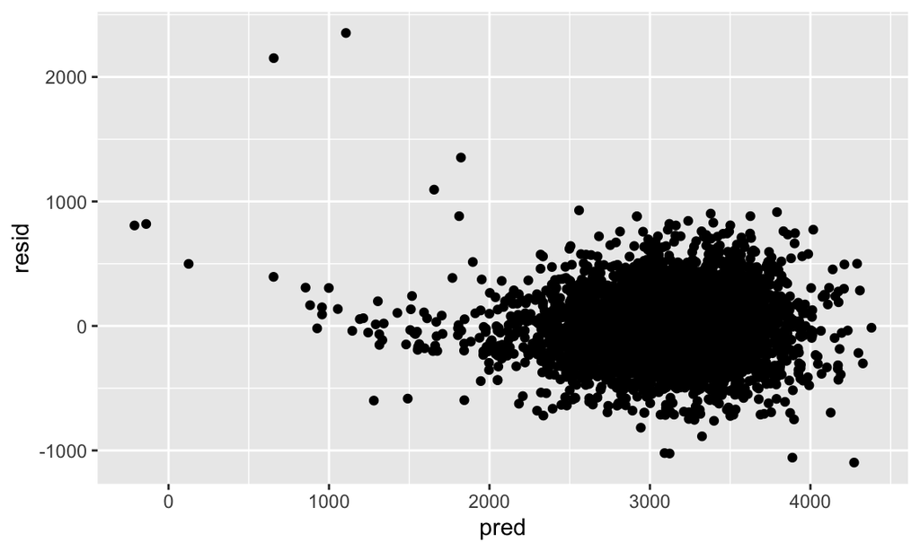

```r
bweight = modelr::add_residuals(bweight, reg)
modelr::add_predictions(bweight, reg) %>%
  ggplot(aes(x = pred, y = resid)) + geom_point()
```

The plot illustrates the majority of values as being centered around a residual value of 0 and predicted value between 2500 and 3500. As the predicted weight values get very small, however, we see higher residual values, which suggest that this model performs well for average and above average weight babies, but not as well for lower weight babies.

Now I will generate two additional models to compare my model to. These include: (1) a simple model containing only baby length and gestational week as predictors, and (2) a model containing baby length, head circumference, sex, and the three-way interactions of these variables.

```r
## Predictors = length and gesitational age
simple = lm(bwt ~ blength + gaweeks, data = bweight)
simple %>%
  broom::glance()
```

```
## # A tibble: 1 x 12
##   r.squared adj.r.squared sigma statistic p.value    df  logLik    AIC    BIC
##       <dbl>         <dbl> <dbl>     <dbl>   <dbl> <dbl>   <dbl>  <dbl>  <dbl>
## 1     0.577         0.577  333.     2958.       0     2 -31381. 62771. 62796.
## # … with 3 more variables: deviance <dbl>, df.residual <int>, nobs <int>
```

```r
summary(simple)
```

```
##
## Call:
## lm(formula = bwt ~ blength + gaweeks, data = bweight)
##
## Residuals:
##     Min      1Q  Median      3Q     Max
## -1709.6  -215.4   -11.4   208.2  4188.8
##
## Coefficients:
##              Estimate Std. Error t value Pr(>|t|)
## (Intercept) -4347.667     97.958  -44.38   <2e-16 ***
## blength       128.556      1.990   64.60   <2e-16 ***
## gaweeks        27.047      1.718   15.74   <2e-16 ***
## ---
## Signif. codes:  0 '***' 0.001 '**' 0.01 '*' 0.05 '.' 0.1 ' ' 1
##
## Residual standard error: 333.2 on 4339 degrees of freedom
## Multiple R-squared:  0.5769, Adjusted R-squared:  0.5767
## F-statistic:  2958 on 2 and 4339 DF,  p-value: < 2.2e-16
```

```r
## Adjusted R squared = 0.5767

## Predictors = head circumference, length, sex and all interactions
interaction = lm(bwt ~ blength*bhead*babysex, data = bweight)
interaction %>%
  broom::glance()
```

```
## # A tibble: 1 x 12
##   r.squared adj.r.squared sigma statistic p.value    df  logLik    AIC    BIC
##       <dbl>         <dbl> <dbl>     <dbl>   <dbl> <dbl>   <dbl>  <dbl>  <dbl>
## 1     0.685         0.684  288.     1346.       0     7 -30742. 61501. 61559.
## # … with 3 more variables: deviance <dbl>, df.residual <int>, nobs <int>
```

```r
summary(interaction)
```

```
##
## Call:
## lm(formula = bwt ~ blength * bhead * babysex, data = bweight)
##
## Residuals:
##      Min       1Q   Median       3Q      Max
## -1132.99  -190.42   -10.33   178.63  2617.96
##
## Coefficients:
##                          Estimate Std. Error t value Pr(>|t|)
## (Intercept)            -7176.8170  1264.8397  -5.674 1.49e-08 ***
## blength                  102.1269    26.2118   3.896 9.92e-05 ***
## bhead                    181.7956    38.0542   4.777 1.84e-06 ***
## babysex2                6374.8684  1677.7669   3.800 0.000147 ***
## blength:bhead             -0.5536     0.7802  -0.710 0.478012
## blength:babysex2        -123.7729    35.1185  -3.524 0.000429 ***
## bhead:babysex2          -198.3932    51.0917  -3.883 0.000105 ***
## blength:bhead:babysex2     3.8781     1.0566   3.670 0.000245 ***
## ---
## Signif. codes:  0 '***' 0.001 '**' 0.01 '*' 0.05 '.' 0.1 ' ' 1
##
## Residual standard error: 287.7 on 4334 degrees of freedom
## Multiple R-squared:  0.6849, Adjusted R-squared:  0.6844
## F-statistic:  1346 on 7 and 4334 DF,  p-value: < 2.2e-16
```

```r
## Adjusted R squared = 0.6844
```

Now I will compare these models in terms of the cross-validated prediction error.

```r
# use crossv_mc function to partition the data for a test-training split
cv_df =
  crossv_mc(bweight, 4342)

# format the training and testing data as tibbles
cv_df =
  cv_df %>%
  mutate(
    train = map(train, as_tibble),
    test = map(test, as_tibble))

# generate model outputs and rmse for each model
cv_df =
  cv_df %>%
  mutate(
    simple_mod  = map(train, ~lm(bwt ~ blength + gaweeks, data = .x)),
    interaction_mod = map(train, ~lm(bwt ~ blength*bhead*babysex, data = .x)),
    my_mod  = map(train, ~lm(bwt ~ babysex + bhead + blength + delwt + fincome + gaweeks +
    mheight + mrace + parity + ppwt + smoken, data = .x))) %>%
  mutate(
    rmse_simple = map2_dbl(simple_mod, test, ~rmse(model = .x, data = .y)),
    rmse_interaction = map2_dbl(interaction_mod, test, ~rmse(model = .x, data = .y)),
    rmse_backward_step = map2_dbl(my_mod, test, ~rmse(model = .x, data = .y)))
```

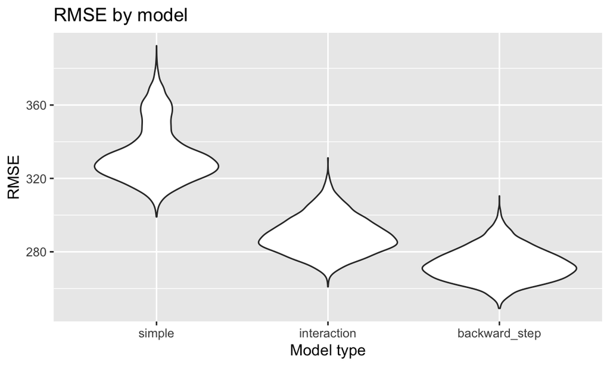

```r
cv_df %>%
  select(starts_with("rmse")) %>%
  pivot_longer(
    everything(),
    names_to = "model",
    values_to = "rmse",
    names_prefix = "rmse_") %>%
  mutate(model = fct_inorder(model)) %>%
  ggplot(aes(x = model, y = rmse)) + geom_violin() +
  labs(
    title = "RMSE by model",
    x = "Model type",
    y = "RMSE"
  )
```

As we can see from this plot, the plot made through backward stepwise selection has the lowest RMSE. Thus, this model performs the best in predicting baby weight.

### Problem 3

For this problem, I will use a dataset documenting weather observed in Central Park. We are interested in predicting the daily reported temperature maximum using the reported temperature minimum as a predictor.

```r
weather_df =
  rnoaa::meteo_pull_monitors(
    c("USW00094728"),
    var = c("PRCP", "TMIN", "TMAX"),
    date_min = "2017-01-01",
    date_max = "2017-12-31") %>%
  mutate(
    name = recode(id, USW00094728 = "CentralPark_NY"),
    tmin = tmin / 10,
    tmax = tmax / 10) %>%
  select(name, id, everything())

# regression model for 1 (weather_df) sample
lm(tmax ~ tmin, data = weather_df) %>%
  broom::tidy() %>%
  knitr::kable(digits = 3)
```

| term | estimate | std.error | statistic | p.value |
| --- | --- | --- | --- | --- |
| (Intercept) | 7.209 | 0.226 | 31.847 | 0 |
| tmin | 1.039 | 0.017 | 61.161 | 0 |

I will use 5000 bootstrap samples to generate estimates for $\hat r^2$ and $log(\beta_0*\beta_1)$ for each bootstrap.

```r
# draw one bootstrap sample
set.seed(1)

boot_sample = function(df) {
  sample_frac(weather_df, replace = TRUE)
}

# draw 5000 bootstrap samples
boot_straps =
  data_frame(
    strap_number = 1:5000,
    strap_sample = rerun(5000, boot_sample(weather_df))
  )

# run regression models on 5000 bootstrap samples
bootstrap_results =
  boot_straps %>%
  mutate(
    models = map(strap_sample, ~lm(tmax ~ tmin, data = .x) ),
    results1 = map(models, broom::glance),
    results2 = map(models, broom::tidy)) %>%
  select(strap_number, results1, results2) %>%
  unnest(results1, results2)
```

The mean $\hat r^2$ over all bootstrap samples is calculated as follows:

```r
# find mean r squared over all bootstrap samples
bootstrap_results %>%
  summarize(mean_r_sq = mean(r.squared))
```

```
## # A tibble: 1 x 1
##   mean_r_sq
##       <dbl>
## 1     0.911
```

Now I will generate the $log(\beta_0*\beta_1)$ variable using estimates for $\beta_0$ and $\beta_1$ for each bootstrap.

```r
# generate log(B0*B1) variable
btstrap_log_data =
  bootstrap_results %>%
  select(strap_number, term, estimate) %>%
  pivot_wider(
    names_from = term,
    values_from = estimate) %>%
  rename("B0" = "(Intercept)",
         "B1" = "tmin") %>%
  mutate(
    log_var = log(B0*B1)
  )

# find log(B0*B1) over all bootstrap samples
btstrap_log_data %>%
  summarize(mean_log_var = mean(log_var))
```

```
## # A tibble: 1 x 1
##   mean_log_var
##          <dbl>
## 1         2.01
```

Now I will generate a plot of the distribution of the r squared estimate over all bootstrap samples.

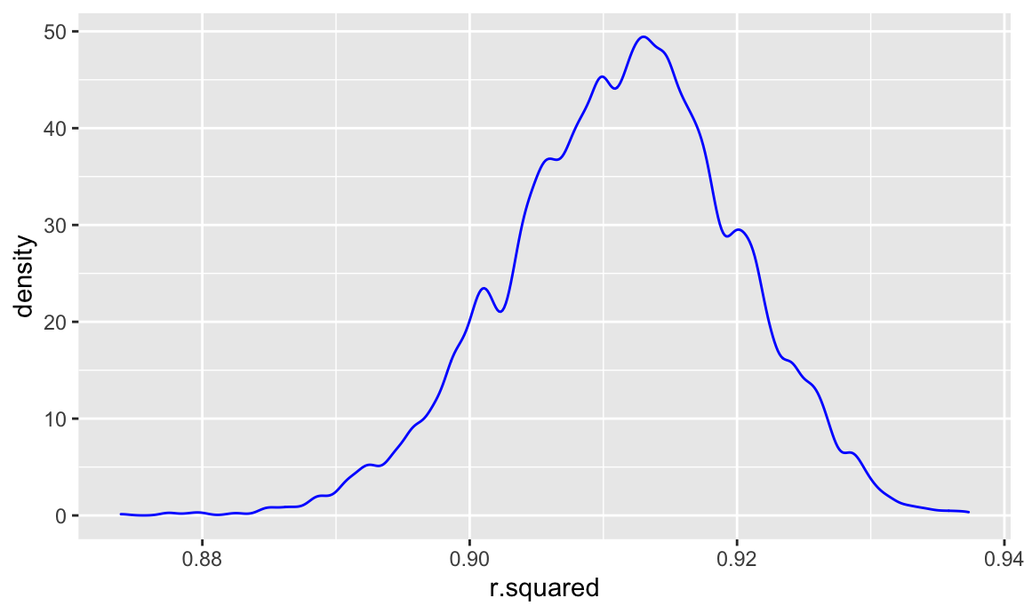

```r
bootstrap_results %>%
  ggplot(aes(x = r.squared)) +
  geom_density(alpha = .4, adjust = .5, color = "blue")
```

Now I will generate a plot of the distribution of the $log(\beta_0*\beta_1)$ estimate over all bootstrap samples.

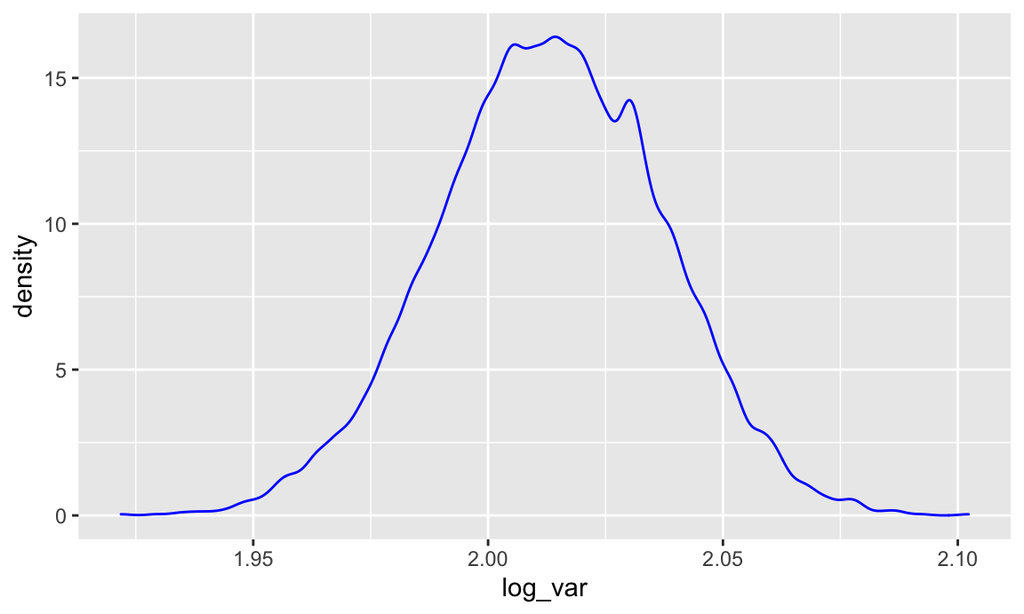

```r
btstrap_log_data %>%
  ggplot(aes(x = log_var)) +
  geom_density(alpha = .4, adjust = .5, color = "blue")
```

```r
## r^2 95% CI
bootstrap_results %>%
  summarize(
    ci_lower = quantile(r.squared, 0.025),
    ci_upper = quantile(r.squared, 0.975))
```

```
## # A tibble: 1 x 2
##   ci_lower ci_upper
##      <dbl>    <dbl>
## 1    0.894    0.927
```

```r
## log(B0*B1) 95% CI
btstrap_log_data %>%
  summarize(
    ci_lower = quantile(log_var, 0.025),
    ci_upper = quantile(log_var, 0.975))
```

```
## # A tibble: 1 x 2
##   ci_lower ci_upper
##      <dbl>    <dbl>
## 1     1.96     2.06
```